# Introduction to advance plotting and maps with R

# Plot a map

First we need a map to plot, lets download a map of the world, I have download the map without boundary lakes from http://www.naturalearthdata.com/ version 4.0.0, the direct link to the download is [here](http://www.naturalearthdata.com/http//www.naturalearthdata.com/download/110m/cultural/ne_110m_admin_0_countries_lakes.zip). I have added the whole folder to a new folder called Maps located in my working file (where my Rproject is), remember that for accesing it you need to write the exact adress as you have it in the folders!

```r
library(rgdal)
myworldmap <- readOGR("Maps/ne_110m_admin_0_countries_lakes/ne_110m_admin_0_countries_lakes.shp",
                      verbose = FALSE)

# We can check its structure by using
#str(myworldmap)

# We can access their data by
#head(myworldmap@data)
```

We can know plot the map and add a color red to one country

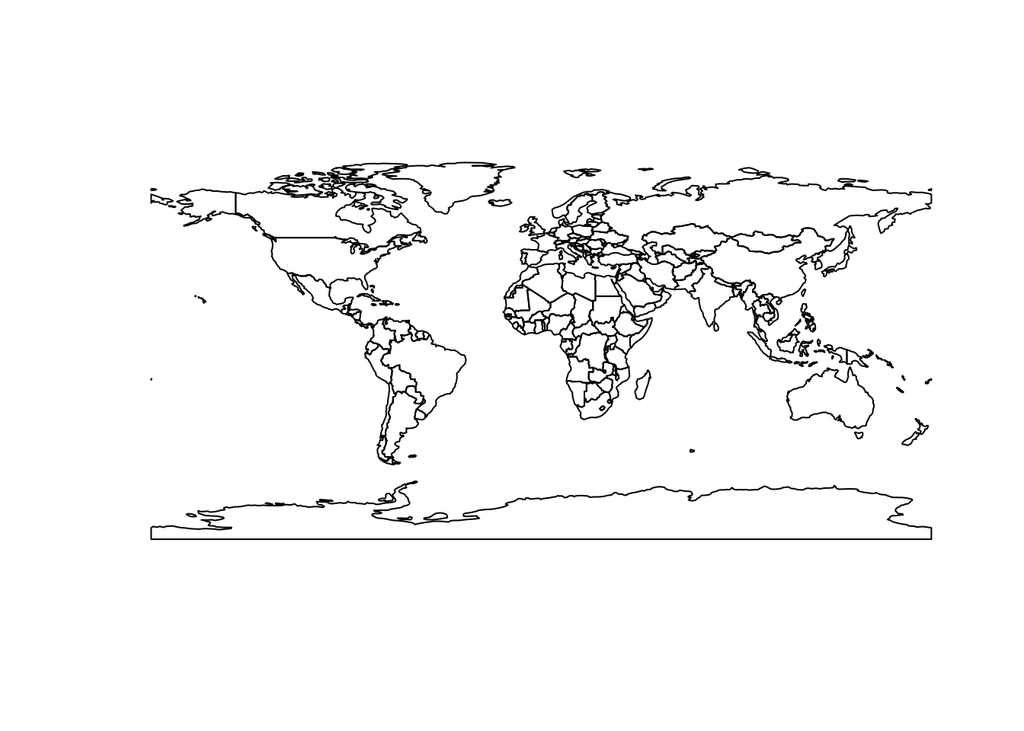

```r
library(rgdal)
myworldmap <- readOGR("Maps/ne_110m_admin_0_countries_lakes/ne_110m_admin_0_countries_lakes.shp",
                      verbose = FALSE)
plot(myworldmap)
```

Now we can color in red the countries where we were born

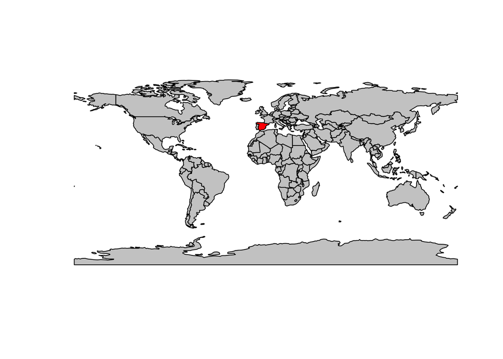

```r
library(rgdal)
myworldmap <- readOGR("Maps/ne_110m_admin_0_countries_lakes/ne_110m_admin_0_countries_lakes.shp",
                       verbose = FALSE)

#You can check the whole list of country names
# myworldmap@data$NAME
myCountries = myworldmap@data$NAME %in% c("Spain")
plot(myworldmap, col = c(gray(.80), "red")[myCountries+1])
```

If you want to add come extra colors you can subset some of the contries, color them and then add it to the previous plot, something like this

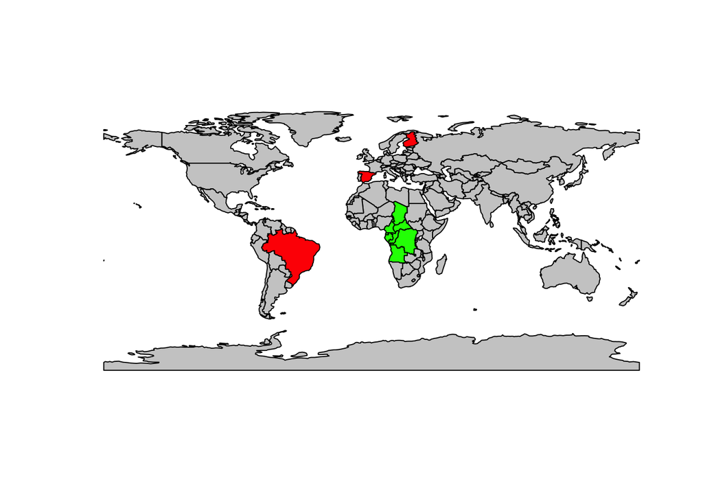

```r
library(rgdal)
myworldmap <- readOGR("Maps/ne_110m_admin_0_countries_lakes/ne_110m_admin_0_countries_lakes.shp",
                       verbose = FALSE)

#You can check the whole list of country names
# myworldmap@data$NAME
myCountries = myworldmap@data$NAME %in% c("Spain", "Finland", "Brazil")
plot(myworldmap, col = c(gray(.80), "red")[myCountries+1])

MiddleAfrica <- myworldmap[myworldmap@data$SUBREGION == "Middle Africa", ]
plot(MiddleAfrica, col = "green", add = TRUE)
```

You can also plot maps using ggplot2, [here](http://eriqande.github.io/rep-res-web/lectures/making-maps-with-R.html) there is a tutorial that you can follow.